####*Objective 5. Normalize the filtered expression data and plot*

Packages used in this notebook: `edgeR`, `RColorBrewer`. First verify that they are installed and loaded.

Now we should normalize the filtered expression data in case there were any issues with our samples. These values can go in the `norm.factors` column of the samples part of our filtered DGEList object `dge_sub`.

```r
dge_sub$samples
```

|  | files | group | lib.size | norm.factors |
| --- | --- | --- | --- | --- |
| GSM1545535_10_6_5_11 | GSM1545535_10_6_5_11.txt | LP | 32863052 | 1 |
| GSM1545536_9_6_5_11 | GSM1545536_9_6_5_11.txt | ML | 35335491 | 1 |
| GSM1545538_purep53 | GSM1545538_purep53.txt | Basal | 57160817 | 1 |
| GSM1545539_JMS8-2 | GSM1545539_JMS8-2.txt | Basal | 51368625 | 1 |
| GSM1545540_JMS8-3 | GSM1545540_JMS8-3.txt | ML | 75795034 | 1 |
| GSM1545541_JMS8-4 | GSM1545541_JMS8-4.txt | LP | 60517657 | 1 |
| GSM1545542_JMS8-5 | GSM1545542_JMS8-5.txt | Basal | 55086324 | 1 |
| GSM1545544_JMS9-P7c | GSM1545544_JMS9-P7c.txt | ML | 21311068 | 1 |
| GSM1545545_JMS9-P8c | GSM1545545_JMS9-P8c.txt | LP | 19958838 | 1 |

There are a number of different packages that will do this (some may work better than others!), but we’ll use the `calcNormFactors()` from the `edgeR` package.

```r
?calcNormFactors
dge_sub_norm <- calcNormFactors(dge_sub, method = "TMM")
dge_sub_norm$samples
```

|  | files | group | lib.size | norm.factors |
| --- | --- | --- | --- | --- |
| GSM1545535_10_6_5_11 | GSM1545535_10_6_5_11.txt | LP | 32863052 | 0.8959157 |
| GSM1545536_9_6_5_11 | GSM1545536_9_6_5_11.txt | ML | 35335491 | 1.0349283 |
| GSM1545538_purep53 | GSM1545538_purep53.txt | Basal | 57160817 | 1.0438217 |
| GSM1545539_JMS8-2 | GSM1545539_JMS8-2.txt | Basal | 51368625 | 1.0403655 |
| GSM1545540_JMS8-3 | GSM1545540_JMS8-3.txt | ML | 75795034 | 1.0325649 |
| GSM1545541_JMS8-4 | GSM1545541_JMS8-4.txt | LP | 60517657 | 0.9224669 |
| GSM1545542_JMS8-5 | GSM1545542_JMS8-5.txt | Basal | 55086324 | 0.9834755 |
| GSM1545544_JMS9-P7c | GSM1545544_JMS9-P7c.txt | ML | 21311068 | 1.0824912 |
| GSM1545545_JMS9-P8c | GSM1545545_JMS9-P8c.txt | LP | 19958838 | 0.9793867 |

```r
dge_sub$counts[,1] <- dge_sub$counts[,1]*0.05
dge_sub$counts[,2] <- dge_sub$counts[,2]*5

log2cpm_unorm <- cpm(dge_sub, log=TRUE)
log2cpm_norm <- cpm(dge_sub_norm, log=TRUE)
```

Now we can make side-by-side box plots to show the differences before and after normalization (especially for the two samples that we messed up intentionally).

```r
par(mfrow=c(1,2))
boxplot(log2cpm_unorm,
    las=2,
    col=col,
    main="")
title(main="A. Unnormalized data",ylab="Log2(CPM)")
```

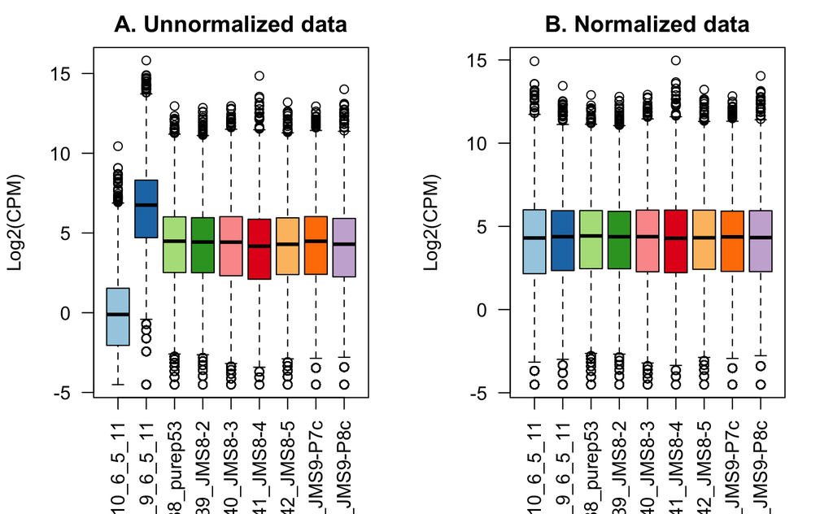

```r
boxplot(log2cpm_norm,
    las=2,
    col=col,
    main="")
title(main="B. Normalized data",ylab="Log2(CPM)")
```